# Exercício 2

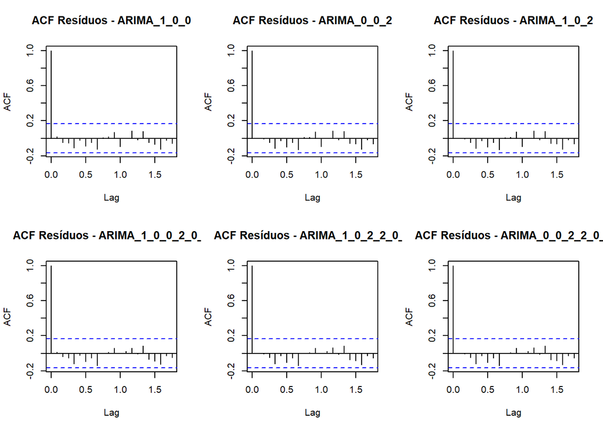

```r
# Modelos

model_list <- list(
  ARIMA_1_0_0       = arima(train_ts, order = c(1,0,0), seasonal = c(0,0,0), xreg = xreg_train),
  ARIMA_0_0_2       = arima(train_ts, order = c(0,0,2), seasonal = c(0,0,0), xreg = xreg_train),
  ARIMA_1_0_2       = arima(train_ts, order = c(1,0,2), seasonal = c(0,0,0), xreg = xreg_train),
  ARIMA_1_0_0_2_0_0 = arima(train_ts, order = c(1,0,0), seasonal = c(2,0,0), xreg = xreg_train),
  ARIMA_1_0_2_2_0_0 = arima(train_ts, order = c(1,0,2), seasonal = c(2,0,0), xreg = xreg_train),
  ARIMA_0_0_2_2_0_0 = arima(train_ts, order = c(0,0,2), seasonal = c(2,0,0), xreg = xreg_train)
)


# Diagnóstico dos resíduos

par(mfrow = c(2, 3))

for(nome in names(model_list)) {
  res <- residuals(model_list[[nome]])
  res <- na.omit(res)   # remover NAs
  acf(res, main = paste("ACF Resíduos -", nome))
}
```

```r
get_coefs <- function(model, nome_modelo) {
  coefs <- coef(model)
  tibble(
    Modelo = nome_modelo,
    Coeficiente = names(coefs),
    Valor = as.numeric(coefs)
  )
}


coef_list <- lapply(names(model_list), function(nome) {
  get_coefs(model_list[[nome]], nome)
})

coef_tibble <- bind_rows(coef_list)


coef_wide <- coef_tibble %>%
  pivot_wider(names_from = Coeficiente, values_from = Valor)


kable(coef_wide, digits = 4)
```

| Modelo | ar1 | intercept | fx | commodity_fertilizers | soybean_prod | exp_value | el_nino | soybean_global_price | ma1 | ma2 | sar1 | sar2 |
| --- | --- | --- | --- | --- | --- | --- | --- | --- | --- | --- | --- | --- |
| ARIMA_1_0_0 | 0.2595 | 0.4575 | 0.1762 | -0.0264 | -0.0277 | 0.0065 | -0.0327 | 0.6076 | NA | NA | NA | NA |
| ARIMA_0_0_2 | NA | 0.4383 | 0.1881 | -0.0247 | -0.0266 | 0.0064 | -0.0324 | 0.6047 | 0.2783 | 0.0232 | NA | NA |
| ARIMA_1_0_2 | -0.0714 | 0.4390 | 0.1885 | -0.0248 | -0.0266 | 0.0064 | -0.0324 | 0.6045 | 0.3494 | 0.0431 | NA | NA |
| ARIMA_1_0_0_2_0_0 | 0.2511 | 0.4709 | 0.1997 | -0.0214 | -0.0284 | 0.0066 | -0.0318 | 0.6156 | NA | NA | -0.1153 | 0.0819 |
| ARIMA_1_0_2_2_0_0 | 0.0682 | 0.4546 | 0.2092 | -0.0197 | -0.0275 | 0.0065 | -0.0320 | 0.6104 | 0.2005 | 0.0121 | -0.1176 | 0.0690 |
| ARIMA_0_0_2_2_0_0 | NA | 0.4547 | 0.2093 | -0.0199 | -0.0275 | 0.0065 | -0.0320 | 0.6103 | 0.2689 | 0.0323 | -0.1176 | 0.0699 |

- De modo geral, os modelos apresentaram bom desempenho preditivo, sendo o ARIMA(1,0,0) o melhor deles segundo o RMSE fora da amostra. Em comparação com o exercício anterior, observa-se que as diferenças entre o melhor modelo da corrida e o ARIMA(1,0,0)(2,0,0) não geram implicações relevantes para a performance das previsões. Assim, por conveniência e em razão das métricas ligeiramente superiores de acurácia, optou-se por adotar o modelo selecionado na corrida com o melhor do método.

```r
# Função de métricas de validação

get_metrics <- function(model, nome_modelo) {

  res <- residuals(model)
  rmse_in <- sqrt(mean(res^2, na.rm = TRUE))


  fc <- predict(model, n.ahead = n_test, newxreg = xreg_test)

  rmse_out <- sqrt(mean((test_ts - fc$pred)^2, na.rm = TRUE))
  mae_out  <- mean(abs(test_ts - fc$pred), na.rm = TRUE)
  mape_out <- mean(abs((test_ts - fc$pred)/test_ts)) * 100


  lb_test <- Box.test(res, lag = 12, type = "Ljung-Box")
  lb_pval <- lb_test$p.value

  tibble(
    Modelo     = nome_modelo,
    RMSE_in    = round(rmse_in, 4),
    RMSE_out   = round(rmse_out, 4),
    MAE_out    = round(mae_out, 4),
    MAPE_out   = round(mape_out, 4),
    AIC        = round(AIC(model), 4),
    BIC        = round(BIC(model), 4),
    LjungBox_p = round(lb_pval, 4)
  )
}



# Tabela de métricas de validação
metrics_tibble <- bind_rows(
  lapply(names(model_list), function(nome) get_metrics(model_list[[nome]], nome))
)
kable(metrics_tibble)
```

| Modelo | RMSE_in | RMSE_out | MAE_out | MAPE_out | AIC | BIC | LjungBox_p |
| --- | --- | --- | --- | --- | --- | --- | --- |
| ARIMA_1_0_0 | 0.0318 | 0.0415 | 0.0288 | 77.5107 | -554.3130 | -527.7742 | 0.7330 |
| ARIMA_0_0_2 | 0.0317 | 0.0416 | 0.0290 | 79.0176 | -552.8582 | -523.3706 | 0.7257 |
| ARIMA_1_0_2 | 0.0317 | 0.0416 | 0.0290 | 79.0432 | -550.8622 | -518.4258 | 0.7274 |
| ARIMA_1_0_0_2_0_0 | 0.0315 | 0.0430 | 0.0286 | 69.6745 | -552.5613 | -520.1249 | 0.7844 |
| ARIMA_1_0_2_2_0_0 | 0.0315 | 0.0431 | 0.0288 | 69.8632 | -548.9308 | -510.5969 | 0.7695 |
| ARIMA_0_0_2_2_0_0 | 0.0315 | 0.0431 | 0.0288 | 69.8703 | -550.9445 | -515.5594 | 0.7744 |

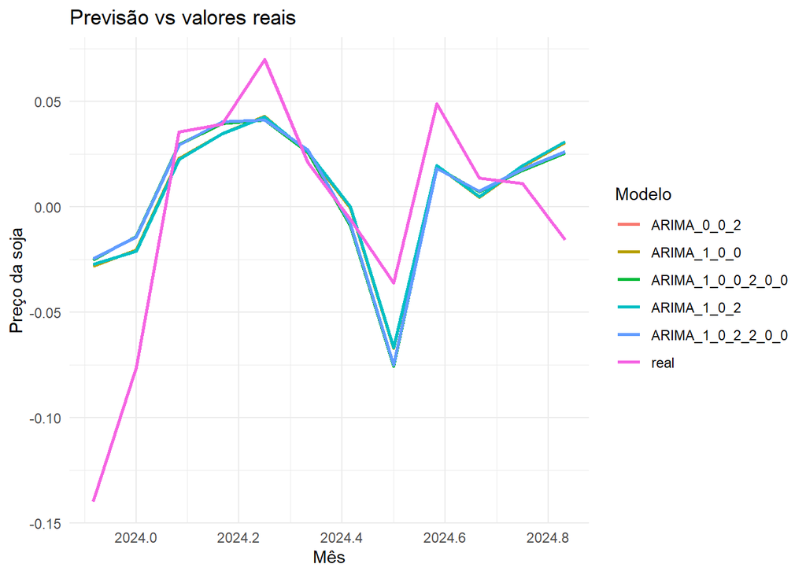

```r
# Gráficos de previsão vs real

forecast_list <- lapply(model_list, function(mod) {
  predict(mod, n.ahead = n_test, newxreg = xreg_test)$pred
})

plot_df <- data.frame(
  ds                   = time(test_ts),
  real                 = as.numeric(test_ts),
  ARIMA_1_0_0          = as.numeric(forecast_list[[1]]),
  ARIMA_0_0_2          = as.numeric(forecast_list[[2]]),
  ARIMA_1_0_2          = as.numeric(forecast_list[[3]]),
  ARIMA_1_0_0_2_0_0    = as.numeric(forecast_list[[4]]),
  ARIMA_1_0_2_2_0_0    = as.numeric(forecast_list[[5]])
)

plot_df_long <- plot_df %>%
  pivot_longer(cols = -ds, names_to = "Modelo", values_to = "Valor")

ggplot(plot_df_long, aes(x = ds, y = Valor, color = Modelo)) +
  geom_line(size = 1) +
  labs(title = "Previsão vs valores reais",
       x = "Mês", y = "Preço da soja") +
  theme_minimal()
```

# Prophet

- Para a aplicação do Prophet, utilizou-se o mesmo conjunto de dados do modelo anterior. Entretanto, a corrida de modelos foi implementada por meio de um loop, que gerou todas as combinações possíveis de variáveis exógenas. A partir dessas combinações, foram selecionados os cinco melhores modelos com base no critério de acurácia de menor RMSE fora da amostra.

```r
# Preparar série temporal

df_prophet_pp <- df_model %>%
  mutate(ds = date,
         y = soybean_price) %>%
  select(ds, y)

n_total_pp <- nrow(df_prophet_pp)
n_test_pp  <- 12
n_train_pp <- n_total_pp - n_test_pp

train_df_pp <- df_prophet_pp[1:n_train_pp, ]
test_df_pp  <- df_prophet_pp[(n_train_pp + 1):n_total_pp, ]

# Preparar regressores exógenos

xreg_names_pp <- colnames(xreg)

xreg_train_pp <- xreg[1:n_train_pp, , drop = FALSE] %>%
  as.data.frame() %>%
  mutate(across(everything(), ~ ifelse(is.na(.), mean(., na.rm = TRUE), .)))

xreg_test_pp <- xreg[(n_train_pp + 1):n_total_pp, , drop = FALSE] %>%
  as.data.frame() %>%
  mutate(across(everything(), ~ ifelse(is.na(.), mean(., na.rm = TRUE), .)))

# Função para rodar Prophet dado um subconjunto de regressores

rodar_prophet_pp <- function(vars_pp) {
  df_train_pp_comb <- bind_cols(train_df_pp, xreg_train_pp[, vars_pp, drop = FALSE])

  m_pp <- prophet(yearly.seasonality = TRUE, weekly.seasonality = FALSE, daily.seasonality = FALSE)

  for (v_pp in vars_pp) {
    m_pp <- add_regressor(m_pp, v_pp)
  }

  m_pp <- fit.prophet(m_pp, df_train_pp_comb)

  future_pp <- make_future_dataframe(m_pp, periods = n_test_pp, freq = "month")

  for (v_pp in vars_pp) {
    future_pp[[v_pp]] <- c(xreg_train_pp[[v_pp]], xreg_test_pp[[v_pp]])
  }

  fc_pp <- predict(m_pp, future_pp)
  pred_out_pp <- fc_pp$yhat[(n_train_pp + 1):n_total_pp]

  res_in_pp <- train_df_pp$y - fc_pp$yhat[1:n_train_pp]
  rmse_in_pp <- sqrt(mean(res_in_pp^2, na.rm = TRUE))
  rmse_out_pp <- sqrt(mean((test_df_pp$y - pred_out_pp)^2, na.rm = TRUE))
  mae_out_pp  <- mean(abs(test_df_pp$y - pred_out_pp), na.rm = TRUE)
  mape_out_pp <- mean(abs((test_df_pp$y - pred_out_pp) / test_df_pp$y)) * 100
  lb_test_pp  <- Box.test(res_in_pp, lag = 12, type = "Ljung-Box")

  tibble(
    Modelo_pp     = paste("Prophet", paste(vars_pp, collapse = "+")),
    Vars_pp       = paste(vars_pp, collapse = ", "),
    RMSE_in_pp    = rmse_in_pp,
    RMSE_out_pp   = rmse_out_pp,
    MAE_out_pp    = mae_out_pp,
    MAPE_out_pp   = mape_out_pp,
    LjungBox_p_pp = lb_test_pp$p.value,
    Predicoes_pp  = list(pred_out_pp)
  )
}


# Rodar para todas as combinações possíveis

todas_comb_pp <- unlist(
  lapply(1:length(xreg_names_pp), function(k) combn(xreg_names_pp, k, simplify = FALSE)),
  recursive = FALSE
)

resultados_pp <- map_dfr(todas_comb_pp, rodar_prophet_pp)


# Selecionar os 5 melhores (menor RMSE_out)

melhores_5_pp <- resultados_pp %>%
  arrange(RMSE_out_pp) %>%
  head(5)

kable(melhores_5_pp%>%
  select(-Vars_pp,-Predicoes_pp))
```

| Modelo_pp | RMSE_in_pp | RMSE_out_pp | MAE_out_pp | MAPE_out_pp | LjungBox_p_pp |
| --- | --- | --- | --- | --- | --- |
| Prophet commodity_fertilizers+el_nino+soybean_global_price | 0.0298582 | 0.0280319 | 0.0206363 | 70.94862 | 0.1158723 |
| Prophet commodity_fertilizers+soybean_prod+el_nino+soybean_global_price | 0.0297791 | 0.0282347 | 0.0205172 | 70.74483 | 0.1237193 |
| Prophet fx+commodity_fertilizers+el_nino+soybean_global_price | 0.0297821 | 0.0288323 | 0.0216334 | 75.37462 | 0.0805913 |
| Prophet commodity_fertilizers+soybean_global_price | 0.0301184 | 0.0290510 | 0.0220051 | 71.77736 | 0.1056035 |
| Prophet commodity_fertilizers+soybean_prod+soybean_global_price | 0.0300130 | 0.0290752 | 0.0216659 | 70.94057 | 0.1301807 |

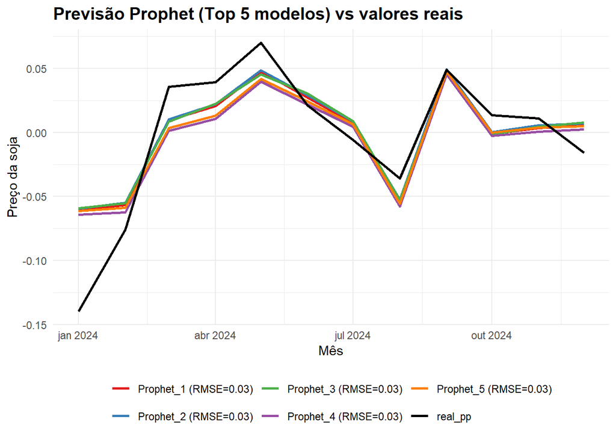

```r
# Plot

plot_df_pp <- tibble(
  ds_pp   = test_df_pp$ds,
  real_pp = test_df_pp$y
)

for (i in 1:nrow(melhores_5_pp)) {
  nome_modelo_pp <- paste0("Prophet_", i, " (RMSE=", round(melhores_5_pp$RMSE_out_pp[i], 2), ")")
  plot_df_pp[[nome_modelo_pp]] <- melhores_5_pp$Predicoes_pp[[i]]
}

plot_df_long_pp <- plot_df_pp %>%
  pivot_longer(cols = -ds_pp, names_to = "Modelo", values_to = "Valor")


ggplot(plot_df_long_pp, aes(x = ds_pp, y = Valor, color = Modelo)) +
  geom_line(size = 1) +
  scale_color_manual(
    values = c(
      "real_pp" = "black",
      setNames(RColorBrewer::brewer.pal(5, "Set1"), colnames(plot_df_pp)[-c(1,2)])
    )
  ) +
  labs(title = "Previsão Prophet (Top 5 modelos) vs valores reais",
       x = "Mês", y = "Preço da soja") +
  theme_minimal() +
  theme(
    legend.position = "bottom",
    legend.title = element_blank(),
    plot.title = element_text(face = "bold", size = 14)
  )
```